# OLIST

# Como reduzir os gastos e maximizar os lucros?

## ANÁLISE BASEADA EM TRÊS HIPÓTESES:

- Vendedores ruins que minimizam o lucro e os reviews
- Tipos de produtos mais suscetíveis e problemas e atrasos
- Regiões do Brasil com mais prejuízos

### Implementando uma política de seleção de vendedores baseadas em resultados!

```python
result_comparison
```

|  | total | categorias positivas | melhores categorias | melhores estados | melhor vendedor |
| --- | --- | --- | --- | --- | --- |
| n_orders | 99844 | 15022 | 77640 | 99449 | 51655 |
| profits | 683665.6 | 396990.01 | 865146.26 | 687337.0 | 1278065.4 |
| it_cost | 500000 | 193942.46 | 440911.86 | 499009.98 | 359637.69 |
| total_profits | 183665.6 | 203047.55 | 424234.4 | 188327.02 | 918427.71 |
| plus_orders | 0 | 0.15 | 0.78 | 1.0 | 0.52 |
| plus_profits | 0 | 1.11 | 2.31 | 1 | 5.0 |

# E como se chegou nessa conclusão?

## O QUE MAIS AFETA OS LUCROS DA OLIST?

### O REVIEW SCORE

Como o review score é correlacionado com cada propriedade de um pedido?

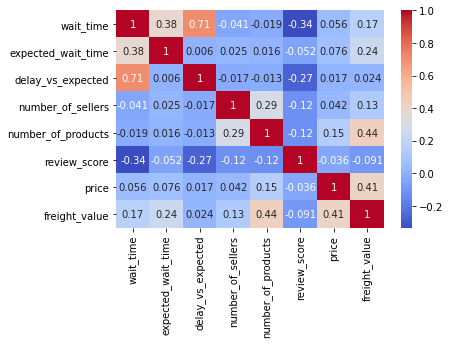

```python
sns.heatmap(orders[columns].corr(), cmap='coolwarm', annot=True)
```

Relação do review score é maior com:

- número de produtos
- número de vendedores
- tempo de atraso na entrega
- tempo de espera

## Correlacionando essas variáveis...

Aplicando um modelo de regressão nos dados, vemos que há pouca relação entre review score e outras variáveis

```python
model5 = smf.ols(formula='review_score_z ~ wait_time_z + number_of_products_z \
    + distance_seller_customer_z + delay_vs_expected_z', data=orders1).fit()
model5.rsquared
```

```
0.13604752362397832
```

Valor de R muito inferior, o que pode indicar que um fator externo aos pedidos afetam o review score

## TALVEZ O PROBLEMA POSSA ESTAR COM OUTRAS VARIÁVEIS

### Avaliando o texto dos reviews para tentar obter algum padrão

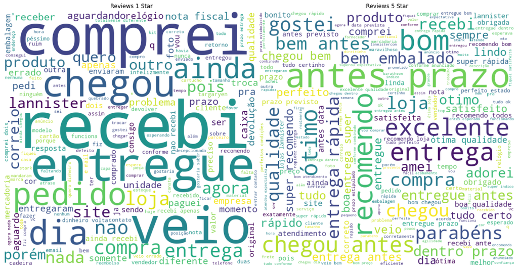

```python
fig, axs = plt.subplots(1,2, figsize=(15,15))
axs[0].imshow(wordcloud1)
axs[0].axis("off")
axs[0].set_title('Reviews 1 Star')
plt.tight_layout(pad = 0)
axs[1].imshow(wordcloud5)
axs[1].axis("off")
axs[1].set_title('Reviews 5 Star')
plt.tight_layout(pad = 0)
```

## TALVEZ O PROBLEMA POSSA ESTAR COM OS TIPOS DE PRODUTOS

### Vamos comparar categorias, com o tempo de espera e a avaliação

### Verifica-se algumas categorias que tem resultado pior que outras

```python
categories.sort_values('cost', ascending=False, inplace=True)
categories['revenues'] = round(categories['sales'] * 0.1, 2)
categories['cost_vs_revenues'] = round(categories['cost'] / categories['revenues'], 4)
categories[['cost', 'n_orders', 'revenues', 'profits', 'cost_vs_revenues']].sort_values('profits').head()
_.style.applymap(lambda x : 'color: red' if x < 0 else 'color: black')
```

| category | cost | n_orders | revenues | profits | cost_vs_revenues |
| --- | --- | --- | --- | --- | --- |
| bed_bath_table | 210510 | 10120 | 103291.790000 | -107218.212000 | 2.038000 |
| furniture_decor | 127770 | 6717 | 71976.440000 | -55793.561000 | 1.775200 |
| telephony | 77080 | 4264 | 31906.180000 | -45173.820000 | 2.415800 |
| computers_accessories | 125430 | 6841 | 89984.370000 | -35445.626000 | 1.393900 |
| housewares | 91440 | 5963 | 62427.130000 | -29012.868000 | 1.464700 |

## Entretanto, aplicando um modelo de regressão, verifica-se que o resultado tem mais relação com o tempo de espera do que com a categoria

```python
model1 = smf.ols(formula = 'review_score ~ wait_time + C(category)', data=products).fit()
results_summary = model1.summary()
results_as_html = results_summary.tables[1].as_html()
pd.read_html(results_as_html, header=0, index_col=0)[0].sort_values('coef').head()
```

|  | coef | std err | t | P>\|t\| | [0.025 | 0.975] |
| --- | --- | --- | --- | --- | --- | --- |
| C(category)[T.security_and_services] | -1.2842 | 0.791 | -1.623 | 0.105 | -2.835 | 0.266 |
| C(category)[T.furniture_mattress_and_upholstery] | -0.4382 | 0.373 | -1.176 | 0.240 | -1.169 | 0.292 |
| C(category)[T.tablets_printing_image] | -0.2511 | 0.390 | -0.643 | 0.520 | -1.016 | 0.514 |
| C(category)[T.fashio_female_clothing] | -0.2044 | 0.253 | -0.808 | 0.419 | -0.700 | 0.291 |
| C(category)[T.fashion_male_clothing] | -0.1660 | 0.176 | -0.945 | 0.344 | -0.510 | 0.178 |

# AVALIANDO OS VENDEDORES: a chave para o sucesso

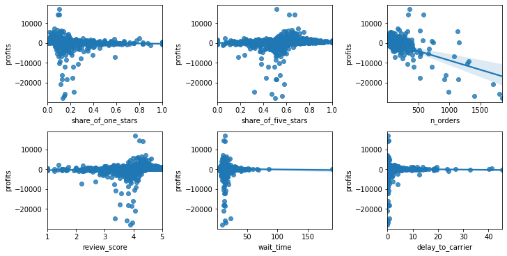

```python
fig = plt.figure(constrained_layout=True, figsize=(10, 5))
gs = fig.add_gridspec(2, 3)
ax1 = fig.add_subplot(gs[0, 0])
sns.regplot(x=sellers['share_of_one_stars'], y=sellers['profits'], ax=ax1)
ax2 = fig.add_subplot(gs[0, 1])
sns.regplot(x=sellers['share_of_five_stars'], y=sellers['profits'], ax=ax2)
ax3 = fig.add_subplot(gs[0, 2])
sns.regplot(x=sellers['n_orders'], y=sellers['profits'], ax=ax3)
ax4 = fig.add_subplot(gs[1, 0])
sns.regplot(x=sellers['review_score'], y=sellers['profits'], ax=ax4)
ax5 = fig.add_subplot(gs[1, 1])
sns.regplot(x=sellers['wait_time'], y=sellers['profits'], ax=ax5)
ax6 = fig.add_subplot(gs[1, 2])
sns.regplot(x=sellers['delay_to_carrier'], y=sellers['profits'], ax=ax6)
```

## Mas que características do vendedor afetam os lucros?

```python
model = smf.ols(formula = 'profits ~ n_orders', data=sellers).fit()
print(f"numero de ordens: {model.rsquared}")
model = smf.ols(formula = 'profits ~ share_of_one_stars', data=sellers).fit()
print(f"share of one star: {model.rsquared}")
model = smf.ols(formula = 'profits ~ share_of_five_stars', data=sellers).fit()
print(f"share of five star: {model.rsquared}")
model = smf.ols(formula = 'profits ~ review_score', data=sellers).fit()
print(f"review score: {model.rsquared}")
model = smf.ols(formula = 'profits ~ review_score + n_orders', data=sellers).fit()
print(f"review score + numero de ordens: {model.rsquared}")
```

```
numero de ordens: 0.3621443382151418
share of one star: 0.008187094440245457
share of five star: 0.005813620722025181
review score: 0.010479023857294822
review score + numero de ordens: 0.37144440578891946
```

## Uma outra relação que pode ser avaliada são vendas por estados

```python
states = sellers.groupby('seller_state').sum()
states[['wait_time', 'n_orders', 'quantity', 'sales', 'revenues', 'profits']].sort_values('profits').head()
```

| seller_state | wait_time | n_orders | quantity | sales | revenues | profits |
| --- | --- | --- | --- | --- | --- | --- |
| MA | 17.825847 | 392 | 406 | 36408.95 | 4200.90 | -3669.10 |
| AM | 47.840802 | 3 | 3 | 1177.00 | 197.70 | -2.30 |
| PA | 13.427086 | 8 | 8 | 1238.00 | 443.80 | 363.80 |
| PI | 13.681893 | 12 | 12 | 2522.00 | 812.20 | 612.20 |
| RO | 32.690481 | 14 | 14 | 4762.20 | 1356.22 | 1056.22 |

## Verifica-se que a exclusão de somente dois estados (MA e AM) altera pouco o resultado final. Então, apesar de ser uma estratégia possível, talves não é indicada ainda neste momento

# Então, e se definirmos metas para os vendedores?

```python
@interact
def plot_polynom(a=widgets.IntSlider(min=0, max=10000, step=1, value=0)):
    print(f"TOTAL - n° orders: {N_ORDERS.sum()}, lucro: R$ {round(PROFITS.sum(), 2)}")
    print(f"ATUALIZADO - n° orders: {N_ORDERS[a:].sum()}, lucro: R$ {round(PROFITS[a:].sum(), 2)}")
    diferença = N_ORDERS.sum() - N_ORDERS[a:].sum()
    percent_orders = ((N_ORDERS.sum() - N_ORDERS[a:].sum())/N_ORDERS.sum())* 100
    percent_profit = ((PROFITS.sum() - PROFITS[a:].sum())/PROFITS.sum())* 100
    print(f"\nDIFERENÇA:\nMENOS {N_ORDERS.sum() - N_ORDERS[a:].sum()} PEDIDOS\nMAIS R$ {round(PROFITS[a:].sum() - PROFITS.sum(), 2)} DE LUCRO")
    print(f"Redução de {percent_orders}% de ordens e variação de {percent_profit}% em ganhos")
    PROFITS.sort_values().reset_index(drop=True)[a:].cumsum().plot()
```

# Então, chegamos a nossa solução para o aumento dos lucros da empresa: a definição de metas para os vendedores!

## Caso contrário, o vendedor poderá ser retirado da plataforma¶

```python
result_comparison
```

|  | total | categorias positivas | melhores categorias | melhores estados | melhor vendedor |
| --- | --- | --- | --- | --- | --- |
| n_orders | 99844 | 15022 | 77640 | 99449 | 51655 |
| profits | 683665.6 | 396990.01 | 865146.26 | 687337.0 | 1278065.4 |
| it_cost | 500000 | 193942.46 | 440911.86 | 499009.98 | 359637.69 |
| total_profits | 183665.6 | 203047.55 | 424234.4 | 188327.02 | 918427.71 |
| plus_orders | 0 | 0.15 | 0.78 | 1.0 | 0.52 |
| plus_profits | 0 | 1.11 | 2.31 | 1 | 5.0 |